# POLS 2972Q

Quantitative Analysis in Political Science

Lecture 19 |

Probability

## Today’s Question

If X ∼ N(0,16), then:

A. X is normally distributed with mean 0 and standard deviation 16

B. X is distributed like a Bernoulli distribution with p=16

C. X is normally distributed with mean 16 and standard deviation 0

D. X is normally distributed with mean 0 and variance 16 (standard deviation 4)

## Plan for Today

- Probability
- Events, Random Variables, and Probability Distributions
- Probability Distributions
  - Bernoulli Distribution
  - Normal Distribution

## Probablity

- There are two different ways of interpreting probability
- According to the frequentist interpretation, the probability of an event is the proportion of its occurrence among infinitely many identical trials
  - Example: probability of heads when flipping a coin
- According to the Bayesian interpretation, probabilities represent one’s subjective beliefs about the relative likelihood of events
  - Example: probability of rain in the afternoon

## Events, Random Variables, and Probability Distributions

- Most things in our lives can be considered **events** (sets of outcomes that occur with a particular probability)
  - Event: being 6 feet or taller
- As soon as we assign a number to an event, we create what is known as a **random variable** (a random variable assigns a numeric value to each mutually exclusive event produced by a trial)
  - random variable tall:

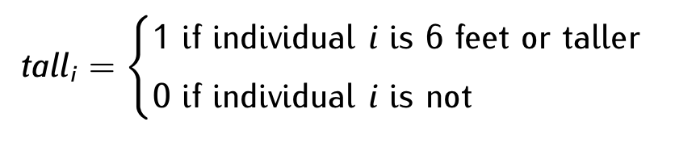

- Each random variable has a probability distribution, which characterizes the likelihood of each value the variable can take
  - Probability distribution of tall:
    - P(tall=1) = probability of being 6 feet or taller
    - P(tall=0) = probability of not being 6 feet or taller
- All probabilities in a distribution must add up to 1

## Probability Distributions

- In chapter 1, we distinguished between binary and non-binary (random) variables
  - Binary variables are . . . .
  - Non-binary variables are . . .
- We will focus on two different types of probability distributions
  - Bernoulli distribution: probability distribution of a binary variable
  - Normal distribution: probability distribution we commonly use as a good approximation for many non-binary variables

## Bernoulli Distribution

- Probability distribution of a binary variable
- It is characterized by one parameter: p
- Recall, all probabilities in a distribution must add up to 1
- If P(X=1) = p, then P(X=0) = 1-p
- If P($\geq$ 6ft =1) = 0.80, then what is P($\leq$ 6ft =0) = ?
- The mean of a Bernoulli distribution is p
- The variance of a Bernoulli distribution is p(1-p)

## Example: Passing This Course

- Event: Passing this course
- Random Variable: pass = {0,1,1,1,1,1,1,1,1,1}
  - Where:

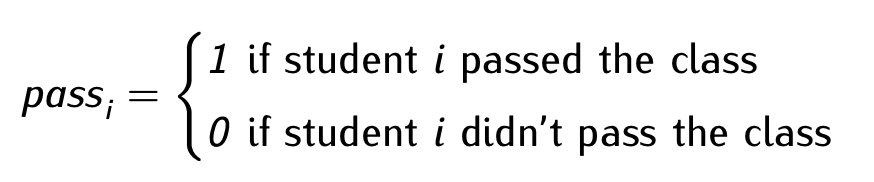

- Probability Distribution: Bernoulli where p = ?
  - P(pass = 1) = p
  - P(pass = 0) = 1 - p

pass = {0,1,1,1,1,1,1,1,1,1}

- What is the probability that pass = 1?
  - What is p?

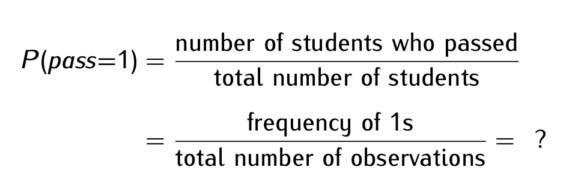

- P(pass = 1) = p = 0.90
  - Interpretation?
    - The probability of passing the class is of 90%

pass = {0,1,1,1,1,1,1,1,1,1}

- What is the probability that pass = 0?
  - What is 1-p?

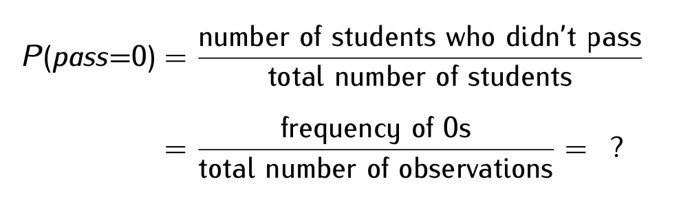

- P(pass = 0) = 1-p = 1 - 0.90 = 0.10
  - Interpretation?
    - The probability of failing the class is of 10%

## Bernoulli Distribution in Action

- Probability for a coin flip

```r
#create a vector with possible values
possible_values <- c(1, 0)


#randomly sample from possible_values
flip <- sample(possible_values,    #vector to draw from
               size = 1000000,     # 1 million times
               replace = TRUE,     #with replacement
               prob = c(0.5, 0.5)) #from a fair coin


#creates a table of proportions
prop.table(table(flip))
```

```
flip
      0       1
0.49966 0.50034
```

```r
#mean
mean(flip)
```

```
[1] 0.50034
```

```r
#variance
var(flip)
```

```
[1] 0.2500001
```

- Do we expect this mean?
  - 0.5 $\times$ 100 = 50%
    - For the Bernoulli, the mean is equivalent to p (here p = 0.5)
- Do we expect this variance?
  - 0.5(1 - 0.5) = 0.25
    - For the Bernoulli, the variance is equivalent to p(1-p)

## Normal Distribution

- Probability distribution we commonly use as a good approximation for many non-binary variables
- It is characterized by two parameters: $\mu$ (mu, the mean) and $\sigma^2$ (sigma-squared, the variance)

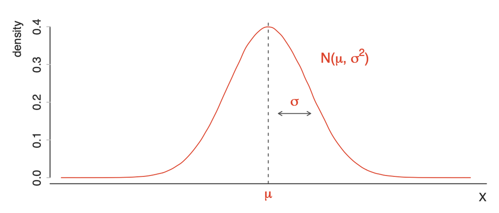

- Normal random variables are variables normally distributed

X ~ N$(\mu, \sigma^2)$

- Examples of the normal distribution

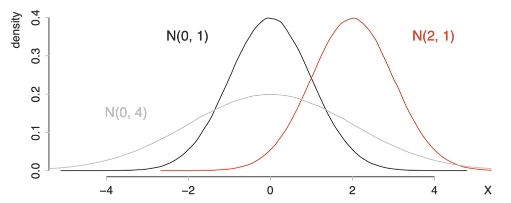

- What is the mean and variance of N(0,1)?
- The probability density function of the normal distribution represents the likelihood of each possible value the normal random variable can take
- We can use it to compute the probability that X takes a value within a given range:

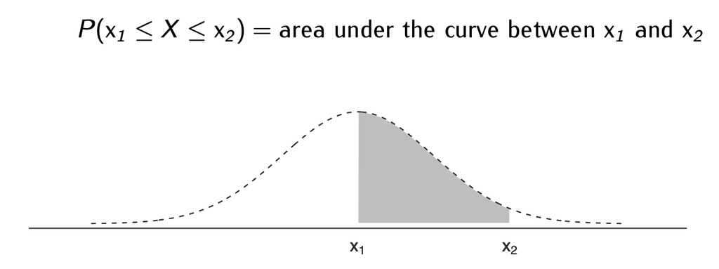

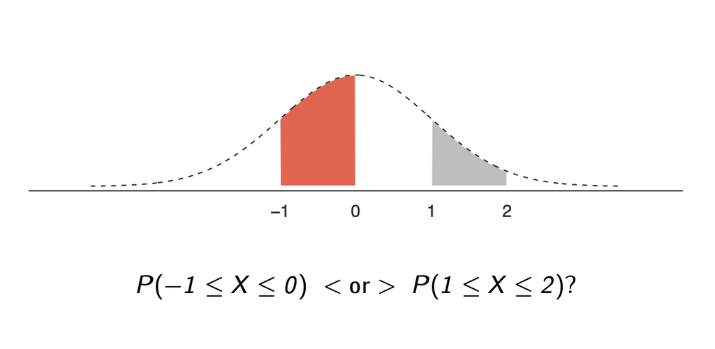